# Topic transformations

This notebook illustrates how we transform the raw daily time series of topics before estimating the daily factor model.

## Housekeeping

```r
rm(list = ls())
setwd("C:/Users/Philipp/Documents/GitHub/nowcasting-topics/data/")
library(ggplot2)
library(lubridate)
library(dplyr)
library(tidyr)
```

## Load topics

```r
df_raw <- read.csv("./topics/daily_topics.csv")

# add date and weekday variable
df_raw %>%
  mutate(date = make_date(year = df_raw$year,
                         month = df_raw$month,
                         day = df_raw$day),
         weekday = wday(date, label = T)) %>%
  select(year, month, day, weekday, date, everything()) -> df_topics

# get rid of raw df
rm(df_raw)

# inspect first rows of df_topics
head(df_topics)
```

|  | year | month | day | weekday | date | T0 | T1 | T2 | T3 | T4 | T5 | T6 | T7 | T8 | T9 | T10 | T11 | T12 | T13 | T14 | T15 | T16 | T17 | T18 | T19 | T20 | T21 | T22 | T23 | … |
| --- | --- | --- | --- | --- | --- | --- | --- | --- | --- | --- | --- | --- | --- | --- | --- | --- | --- | --- | --- | --- | --- | --- | --- | --- | --- | --- | --- | --- | --- | --- |
| 1 | 1994 | 1 | 3 | Mo | 1994-01-03 | 0.008992797 | 0.01482569 | 0.01394222 | 0.02662199 | 0.02305298 | 0.03710313 | 0.010644279 | 0.004851542 | 0.010970559 | 0.01443415 | 0.02776648 | 0.004143764 | 0.02485506 | 0.014107873 | 0.016020380 | 0.007210802 | 0.02003614 | 0.03709811 | 0.007195743 | 0.01079487 | 0.014132972 | 0.003159903 | 0.007336295 | 0.0041588234 | … |
| 2 | 1994 | 1 | 4 | Di | 1994-01-04 | 0.007465012 | 0.01640745 | 0.02364123 | 0.02497018 | 0.01356456 | 0.03601071 | 0.007430936 | 0.001190215 | 0.009567969 | 0.02305708 | 0.05471340 | 0.004836315 | 0.03400511 | 0.003779968 | 0.023865158 | 0.005274431 | 0.02843130 | 0.02839723 | 0.006691006 | 0.02086163 | 0.015180723 | 0.011855908 | 0.015063892 | 0.0035317026 | … |
| 3 | 1994 | 1 | 5 | Mi | 1994-01-05 | 0.006748038 | 0.01796187 | 0.01945448 | 0.01553999 | 0.01777409 | 0.03401464 | 0.007576195 | 0.006372478 | 0.008327315 | 0.01925707 | 0.02888680 | 0.007768790 | 0.02083153 | 0.011938466 | 0.023566373 | 0.006478405 | 0.02789975 | 0.01881891 | 0.006829891 | 0.02241080 | 0.015270355 | 0.009959555 | 0.013589966 | 0.0004694497 | … |
| 4 | 1994 | 1 | 7 | Fr | 1994-01-07 | 0.016584924 | 0.01481310 | 0.01585587 | 0.02169274 | 0.01659818 | 0.03470087 | 0.015140067 | 0.004650495 | 0.010642011 | 0.01988556 | 0.02843098 | 0.008339961 | 0.01712398 | 0.012073613 | 0.014879374 | 0.006311859 | 0.02787425 | 0.02038927 | 0.018635118 | 0.01685004 | 0.010363644 | 0.015785171 | 0.018007688 | 0.0021275186 | … |
| 5 | 1994 | 1 | 8 | Sa | 1994-01-08 | 0.012936210 | 0.01054692 | 0.02446876 | 0.01860413 | 0.01305096 | 0.03448495 | 0.015649269 | 0.002387246 | 0.003551157 | 0.01236655 | 0.01726399 | 0.004924079 | 0.01837872 | 0.011813283 | 0.020423762 | 0.005174074 | 0.01719842 | 0.02633348 | 0.007481404 | 0.01969017 | 0.023341735 | 0.014952562 | 0.020768017 | 0.0011413701 | … |
| 6 | 1994 | 1 | 10 | Mo | 1994-01-10 | 0.008928092 | 0.01291821 | 0.02162344 | 0.02455024 | 0.01790183 | 0.02677354 | 0.017515171 | 0.006919607 | 0.001914505 | 0.01539928 | 0.04063423 | 0.003289297 | 0.02724075 | 0.014830031 | 0.008605875 | 0.006221470 | 0.02221417 | 0.02644058 | 0.009749745 | 0.01527039 | 0.009427528 | 0.015205950 | 0.013159873 | 0.0045190913 | … |

Note that there are no rows for Sundays and bank holidays when no newspapers were published (e.g. Twelfth Night or 6.1.1994). Need to think about how to deal with this. Basically three options:

1. formulate the model at the daily frequency with `NA` for Sundays and bank holidays
2. formulate the model at the weekdaily frequency with `NA` for bank holidays
3. formulate the model under the assumption that a week contains six days with `NA` for bank holidays

I personally favor 1) or 2). What does Thorsrud/the literature do?

For the time being, I perform the transformations as is!

## Preprocessing and transformations

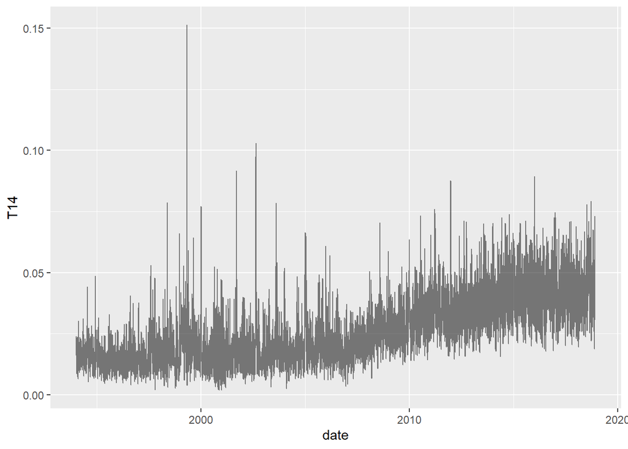

```r
ggplot(df_topics, aes(x = date, y = T14))+geom_line(alpha = 0.5)
```

Standardize topics

```r
# select only topics
dat_orig <- select(df_topics, -year, -month, -day, -date, -weekday)

# standardize
dat <- scale(dat_orig)
```

### Removing outlier

In line with the nowcasting/forecasting literature, we define outlier as those observations as those that are more than 10 interquartiles ranges from the median. Note that this is a very conservative definition!

```r
dt_outl <- function(y, aalpha)
{
  return(abs((y - median(y, na.rm = T))) > aalpha * IQR(y, na.rm = T))
}

ind_outl <- apply(dat, c(2), dt_outl, aalpha = 10)

# number of outliers?
sum(ind_outl)
```

```
## [1] 321
```

In total, there are 321 observations classified as outlier. Set these to `NA`. Note that these missing values will be overwritten, when we smooth the series and detrend them. Therefore we should reimpose the pattern of `NA` obtained at this stage and not use observations that were originally classified as outlier.

```r
dat_rmoutl <- dat
dat_rmoutl[ind_outl] <- NA
```

Visualize series with the most outliers

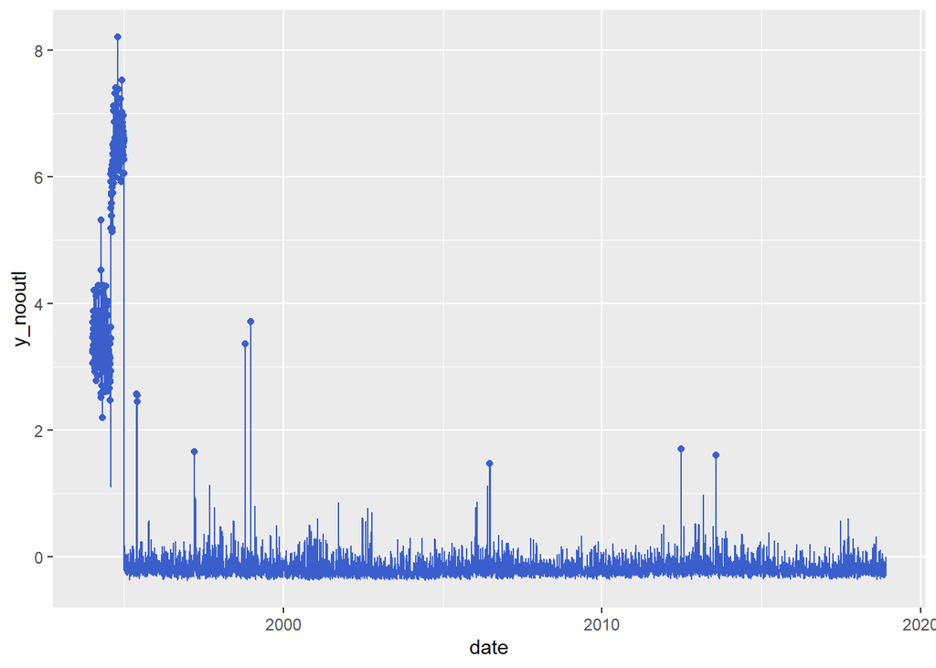

```r
i <- which.max(apply(ind_outl, c(2), sum))
tmp <- array(NA, nrow(dat))
tmp[ind_outl[, i]] <- dat[ind_outl[, i], i]

df_plot <- data.frame(date = df_topics$date,
                      y_nooutl = dat[, i],
                      y_outl = tmp)

ggplot(df_plot)+
  geom_line(aes(x = date, y = y_nooutl), col = "royalblue3")+
  geom_point(aes(x = date, y = y_outl), col = "royalblue3")
```

```r
rm(df_plot, i, tmp)
```

### Smoothing the raw topics

To smooth the topics, we calculate a 60-day backward looking moving average.

`rollmean` function that calculates the recursive $K$-th order rolling mean, i.e. $\hat{y}_t = \frac{1}{K} \sum_{k=0}^K y_{t-k}$. Allows for `NA` in the series.

```r
rollmean <- function(x, k){
  xroll <- array(NA, c(length(x)))
  for (t in seq(k, length(x)))
    xroll[t] <- mean(x[(t-k+1):t], na.rm = TRUE)

  return(xroll)
}
```

```r
# moving average
dat_ma <- apply(dat_rmoutl, c(2), rollmean, k=60)
```

### Removing trends

`bw_filter` function that calculates the bi-weight filter as in [Stock and Watson](https://www.princeton.edu/~mwatson/papers/Stock_Watson_Disentangling_BPEA_2012.pdf) and [Stock and Watson (2016)](https://www.princeton.edu/~mwatson/papers/Stock_Watson_DFM_HOM_030916.pdf). This removes long-run trends in the series but is more flexible than a linear time trend. While in principle two-sided, the filter becomes increasingly one-sided when approaching the endpoints. The function allows for `NA` in the series but only at the beginning!

```r
bw_filter <- function(y, bw)
{
  # compute un-normalized weights
  j <- seq(-bw, bw, 1)
  omeg = (1 - (j/bw) ^ 2) ^ 2

  # check for NA's in y
    n_NA <- sum(is.na(y))
  y_noNA <- y[(n_NA + 1) : length(y)]
  Nt <- length(y_noNA)

  # loop over t
  tau <- mat.or.vec(length(y_noNA), 1)
  for (t in 1 : length(y_noNA)) {
    # case distinction
    if (t <= bw) {

      indY <- c(1 : (2 * bw - (bw - t)))
      indOmeg <- c((bw - t + 1):(2 * bw))
      kap <- 1 / ( sum(omeg[indOmeg]))
      tau[ t ] <- kap * omeg[indOmeg] %*% y_noNA[indY]

    } else if (t > (Nt - bw)) {

      indY <- c((t - bw) : Nt)
      indOmeg <- c(1 : (bw + 1 + (Nt - t)))
      kap <- 1 / ( sum( omeg[indOmeg] ) )
      tau[t] <- kap * omeg[indOmeg] %*% y_noNA[indY]

    } else {

      indY <- seq(t - bw, t + bw, 1)
      indOmeg <- c( 1 : (2 * bw + 1))
      kap <- 1 / (sum(omeg[indOmeg]))
      tau[t] <- kap * omeg[indOmeg] %*% y_noNA[indY]
    }
  }
  return(c(rep(NA, times = n_NA), tau))
}
```

```r
# bi-weight filter
dat_bw <- apply(dat_ma, c(2), bw_filter, bw = 600)

# de-trended topics
dat_trafo <- dat_ma - dat_bw
```

### Plot selected topics

```r
df_orig <- as.data.frame(dat_rmoutl)
df_orig$date <- df_topics$date
df_orig %>%
  pivot_longer(cols = -date, names_to = "topics", values_to = "vals") %>%
  mutate(series = "original") -> df_orig

df_trafo <- as.data.frame(dat_trafo)
df_trafo$date <- df_topics$date
df_trafo %>%
  pivot_longer(cols = -date, names_to = "topics", values_to = "vals") %>%
  mutate(series = "final") -> df_trafo

df_ma <- as.data.frame(dat_ma)
df_ma$date <- df_topics$date
df_ma %>%
  pivot_longer(cols = -date, names_to = "topics", values_to = "vals") %>%
  mutate(series = "smoothed") -> df_ma

df_bw <- as.data.frame(dat_bw)
df_bw$date <- df_topics$date
df_bw %>%
  pivot_longer(cols = -date, names_to = "topics", values_to = "vals") %>%
  mutate(series = "filtered") -> df_bw

# merge into one df
df_plot <- rbind(df_ma, df_bw)
df_plot <- rbind(df_plot, df_orig)
df_plot <- rbind(df_plot, df_trafo)

# convert series to factor and reorder levels
df_plot$series <- as.factor(df_plot$series)
df_plot$series = factor(df_plot$series,levels(df_plot$series)[c(3, 4, 1, 2)])
```

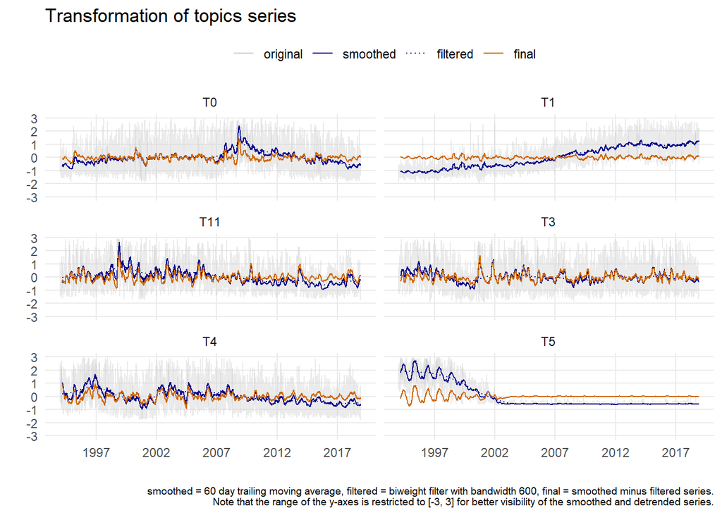

```r
# plot
ylim_uppr <- 3
ylim_lowr <- -ylim_uppr

ggplot(filter(df_plot, topics %in% c("T0", "T1", "T3", "T4", "T5", "T11")),
       aes(x = date, y = vals,
           group = series,
           col = series,
           linetype = series,
           alpha = series
           )
       )+
  geom_line()+
  scale_color_manual(name = element_blank(),
                     values = c("filtered" = "blue4",
                                "smoothed" = "blue4",
                                "original" = "gray80",
                                "final" = "darkorange3"))+
  scale_linetype_manual(name = element_blank(),
                        values = c("filtered" = "dotted",
                                   "smoothed" = "solid",
                                   "original" = "solid",
                                   "final" = "solid"))+
  scale_alpha_manual(name = element_blank(),
                     guide = 'none',
                     values = c("filtered" = 1,
                                "smoothed" = 1,
                                "original" = 0.4,
                                "final" = 1))+
  labs(x = "", y = "",
       title = "Transformation of topics series",
       caption = paste0("smoothed = 60 day trailing moving average, filtered = biweight filter with bandwidth 600, final = smoothed minus filtered series.\nNote that the range of the y-axes is restricted to [", ylim_lowr, ", ", ylim_uppr, "] for better visibility of the smoothed and detrended series."))+
  scale_x_date(date_breaks = "5 years", date_labels = "%Y")+
  scale_y_continuous(breaks = seq(ylim_lowr, ylim_uppr, by = 1), limits = c(ylim_lowr, ylim_uppr))+
  facet_wrap(~ topics , ncol = 2)+
  theme_minimal()+
  theme(legend.position = "top",
        panel.grid.minor = element_blank(),
        #panel.grid.major = element_blank(),
        plot.caption = element_text(size = 7))
```

Save plot as pdf

```r
ggsave(filename = "./topics_trafos.pdf", width = 20, height = 15, units = "cm")
```